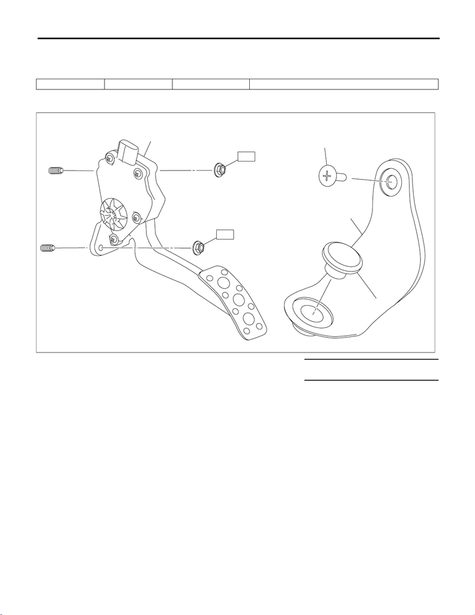

SP(STI)-2

General Description

SPEED CONTROL SYSTEMS

1. General Description

A: SPECIFICATION

B: COMPONENT

Accelerator pedal Stroke At pedal pad 50 — 59 mm (1.97 — 2.32 in)

(1) Accelerator pedal ASSY (3) Accelerator plate Tightening torque: N·m (kgf-m, ft-lb)

(2) Clip (4) Accelerator stopper T: 7.5 (0.8, 5.5)

(1)

(2)

(4)

(3)

SP-02141

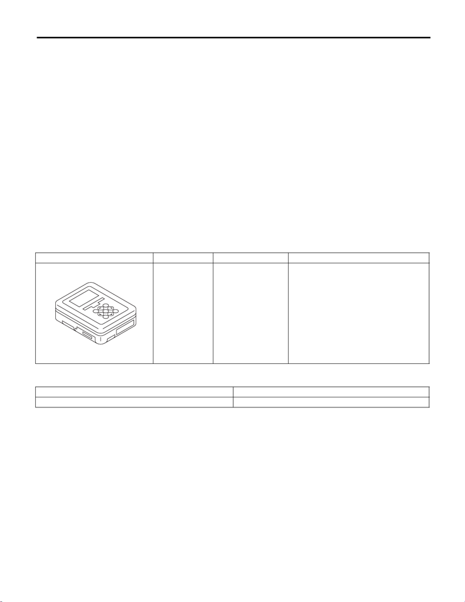

SP(STI)-3

General Description

SPEED CONTROL SYSTEMS

C: CAUTION

• Prior to starting work, pay special attention to the following:

2. Protect the vehicle using a seat cover, fender cover, etc.

3. Prepare the service tools, clean cloth, containers to catch grease and oil, etc.

• Before disconnecting connectors of sensors or units, be sure to disconnect the ground cable from battery.

• Always use the jack-up point when the shop jacks or rigid racks are used to support the vehicle.

• Remove contamination including dirt and corrosion before removal, installation, disassembly or assembly.

• Keep the removed parts in order and protect them from dust and dirt.

• Bolts, nuts and washers should be replaced with new parts as required.

• Be sure to tighten the fasteners including bolts and nuts to the specified torque.

D: PREPARATION TOOL

1. SPECIAL TOOL

2. GENERAL TOOL

ILLUSTRATION TOOL NUMBER DESCRIPTION REMARKS

1B022XU0 SUBARU SELECT

MONITOR III KIT

Used for inspecting the accelerator pedal.

TOOL NAME REMARKS

Circuit tester Used for measuring voltage.

ST1B022XU0